# Risk Factor Analysis

## Outcome Variable

**Outcome Variable:** y_rate_haz

## Predictor Variables

**Intervention Variable:** impfloor

**Adjustment Set:**

unadjusted

## Stratifying Variables

The analysis was stratified on these variable(s):

- agecat
- studyid
- country

## Data Summary

| agecat | studyid | country | impfloor | n_cell | n |
| --- | --- | --- | --- | --- | --- |
| 0-3 months | CMC-V-BCS-2002 | INDIA | 1 | 68 | 68 |
| 0-3 months | CMC-V-BCS-2002 | INDIA | 0 | 0 | 68 |
| 0-3 months | CONTENT | PERU | 1 | 27 | 29 |
| 0-3 months | CONTENT | PERU | 0 | 2 | 29 |
| 0-3 months | GMS-Nepal | NEPAL | 1 | 72 | 398 |
| 0-3 months | GMS-Nepal | NEPAL | 0 | 326 | 398 |
| 0-3 months | IRC | INDIA | 1 | 280 | 280 |
| 0-3 months | IRC | INDIA | 0 | 0 | 280 |
| 0-3 months | MAL-ED | BANGLADESH | 1 | 217 | 236 |
| 0-3 months | MAL-ED | BANGLADESH | 0 | 19 | 236 |
| 0-3 months | MAL-ED | BRAZIL | 1 | 161 | 163 |
| 0-3 months | MAL-ED | BRAZIL | 0 | 2 | 163 |
| 0-3 months | MAL-ED | INDIA | 1 | 166 | 177 |
| 0-3 months | MAL-ED | INDIA | 0 | 11 | 177 |
| 0-3 months | MAL-ED | NEPAL | 1 | 61 | 150 |
| 0-3 months | MAL-ED | NEPAL | 0 | 89 | 150 |
| 0-3 months | MAL-ED | PERU | 1 | 53 | 254 |
| 0-3 months | MAL-ED | PERU | 0 | 201 | 254 |
| 0-3 months | MAL-ED | SOUTH AFRICA | 1 | 178 | 198 |
| 0-3 months | MAL-ED | SOUTH AFRICA | 0 | 20 | 198 |
| 0-3 months | MAL-ED | TANZANIA, UNITED REPUBLIC OF | 1 | 10 | 223 |
| 0-3 months | MAL-ED | TANZANIA, UNITED REPUBLIC OF | 0 | 213 | 223 |
| 0-3 months | NIH-Birth | BANGLADESH | 1 | 501 | 564 |
| 0-3 months | NIH-Birth | BANGLADESH | 0 | 63 | 564 |
| 0-3 months | NIH-Crypto | BANGLADESH | 1 | 547 | 721 |
| 0-3 months | NIH-Crypto | BANGLADESH | 0 | 174 | 721 |
| 0-3 months | PROVIDE | BANGLADESH | 1 | 586 | 640 |
| 0-3 months | PROVIDE | BANGLADESH | 0 | 54 | 640 |
| 3-6 months | CMC-V-BCS-2002 | INDIA | 1 | 214 | 214 |
| 3-6 months | CMC-V-BCS-2002 | INDIA | 0 | 0 | 214 |

[output cut: 194 more lines]

The following strata were considered:

- agecat: 0-3 months, studyid: CMC-V-BCS-2002, country: INDIA
- agecat: 0-3 months, studyid: CONTENT, country: PERU
- agecat: 0-3 months, studyid: GMS-Nepal, country: NEPAL
- agecat: 0-3 months, studyid: IRC, country: INDIA
- agecat: 0-3 months, studyid: MAL-ED, country: BANGLADESH
- agecat: 0-3 months, studyid: MAL-ED, country: BRAZIL
- agecat: 0-3 months, studyid: MAL-ED, country: INDIA
- agecat: 0-3 months, studyid: MAL-ED, country: NEPAL
- agecat: 0-3 months, studyid: MAL-ED, country: PERU
- agecat: 0-3 months, studyid: MAL-ED, country: SOUTH AFRICA
- agecat: 0-3 months, studyid: MAL-ED, country: TANZANIA, UNITED REPUBLIC OF
- agecat: 0-3 months, studyid: NIH-Birth, country: BANGLADESH
- agecat: 0-3 months, studyid: NIH-Crypto, country: BANGLADESH
- agecat: 0-3 months, studyid: PROVIDE, country: BANGLADESH
- agecat: 12-15 months, studyid: CMC-V-BCS-2002, country: INDIA
- agecat: 12-15 months, studyid: CONTENT, country: PERU
- agecat: 12-15 months, studyid: GMS-Nepal, country: NEPAL
- agecat: 12-15 months, studyid: IRC, country: INDIA
- agecat: 12-15 months, studyid: MAL-ED, country: BANGLADESH
- agecat: 12-15 months, studyid: MAL-ED, country: BRAZIL
- agecat: 12-15 months, studyid: MAL-ED, country: INDIA
- agecat: 12-15 months, studyid: MAL-ED, country: NEPAL
- agecat: 12-15 months, studyid: MAL-ED, country: PERU
- agecat: 12-15 months, studyid: MAL-ED, country: SOUTH AFRICA
- agecat: 12-15 months, studyid: MAL-ED, country: TANZANIA, UNITED REPUBLIC OF
- agecat: 12-15 months, studyid: NIH-Birth, country: BANGLADESH
- agecat: 12-15 months, studyid: NIH-Crypto, country: BANGLADESH
- agecat: 12-15 months, studyid: PROVIDE, country: BANGLADESH
- agecat: 15-18 months, studyid: CMC-V-BCS-2002, country: INDIA
- agecat: 15-18 months, studyid: CONTENT, country: PERU
- agecat: 15-18 months, studyid: GMS-Nepal, country: NEPAL
- agecat: 15-18 months, studyid: IRC, country: INDIA
- agecat: 15-18 months, studyid: MAL-ED, country: BANGLADESH
- agecat: 15-18 months, studyid: MAL-ED, country: BRAZIL
- agecat: 15-18 months, studyid: MAL-ED, country: INDIA
- agecat: 15-18 months, studyid: MAL-ED, country: NEPAL
- agecat: 15-18 months, studyid: MAL-ED, country: PERU
- agecat: 15-18 months, studyid: MAL-ED, country: SOUTH AFRICA
- agecat: 15-18 months, studyid: MAL-ED, country: TANZANIA, UNITED REPUBLIC OF
- agecat: 15-18 months, studyid: NIH-Birth, country: BANGLADESH
- agecat: 15-18 months, studyid: NIH-Crypto, country: BANGLADESH
- agecat: 15-18 months, studyid: PROVIDE, country: BANGLADESH
- agecat: 18-21 months, studyid: CMC-V-BCS-2002, country: INDIA
- agecat: 18-21 months, studyid: CONTENT, country: PERU
- agecat: 18-21 months, studyid: GMS-Nepal, country: NEPAL
- agecat: 18-21 months, studyid: IRC, country: INDIA
- agecat: 18-21 months, studyid: MAL-ED, country: BANGLADESH
- agecat: 18-21 months, studyid: MAL-ED, country: BRAZIL
- agecat: 18-21 months, studyid: MAL-ED, country: INDIA
- agecat: 18-21 months, studyid: MAL-ED, country: NEPAL
- agecat: 18-21 months, studyid: MAL-ED, country: PERU
- agecat: 18-21 months, studyid: MAL-ED, country: SOUTH AFRICA
- agecat: 18-21 months, studyid: MAL-ED, country: TANZANIA, UNITED REPUBLIC OF
- agecat: 18-21 months, studyid: NIH-Birth, country: BANGLADESH
- agecat: 18-21 months, studyid: NIH-Crypto, country: BANGLADESH
- agecat: 18-21 months, studyid: PROVIDE, country: BANGLADESH
- agecat: 21-24 months, studyid: CMC-V-BCS-2002, country: INDIA
- agecat: 21-24 months, studyid: CONTENT, country: PERU
- agecat: 21-24 months, studyid: GMS-Nepal, country: NEPAL
- agecat: 21-24 months, studyid: IRC, country: INDIA
- agecat: 21-24 months, studyid: MAL-ED, country: BANGLADESH
- agecat: 21-24 months, studyid: MAL-ED, country: BRAZIL
- agecat: 21-24 months, studyid: MAL-ED, country: INDIA
- agecat: 21-24 months, studyid: MAL-ED, country: NEPAL
- agecat: 21-24 months, studyid: MAL-ED, country: PERU
- agecat: 21-24 months, studyid: MAL-ED, country: SOUTH AFRICA
- agecat: 21-24 months, studyid: MAL-ED, country: TANZANIA, UNITED REPUBLIC OF
- agecat: 21-24 months, studyid: NIH-Birth, country: BANGLADESH
- agecat: 21-24 months, studyid: NIH-Crypto, country: BANGLADESH
- agecat: 21-24 months, studyid: PROVIDE, country: BANGLADESH
- agecat: 3-6 months, studyid: CMC-V-BCS-2002, country: INDIA
- agecat: 3-6 months, studyid: CONTENT, country: PERU
- agecat: 3-6 months, studyid: GMS-Nepal, country: NEPAL
- agecat: 3-6 months, studyid: IRC, country: INDIA
- agecat: 3-6 months, studyid: MAL-ED, country: BANGLADESH
- agecat: 3-6 months, studyid: MAL-ED, country: BRAZIL
- agecat: 3-6 months, studyid: MAL-ED, country: INDIA
- agecat: 3-6 months, studyid: MAL-ED, country: NEPAL
- agecat: 3-6 months, studyid: MAL-ED, country: PERU
- agecat: 3-6 months, studyid: MAL-ED, country: SOUTH AFRICA
- agecat: 3-6 months, studyid: MAL-ED, country: TANZANIA, UNITED REPUBLIC OF
- agecat: 3-6 months, studyid: NIH-Birth, country: BANGLADESH
- agecat: 3-6 months, studyid: NIH-Crypto, country: BANGLADESH
- agecat: 3-6 months, studyid: PROVIDE, country: BANGLADESH
- agecat: 6-9 months, studyid: CMC-V-BCS-2002, country: INDIA
- agecat: 6-9 months, studyid: CONTENT, country: PERU
- agecat: 6-9 months, studyid: GMS-Nepal, country: NEPAL
- agecat: 6-9 months, studyid: IRC, country: INDIA
- agecat: 6-9 months, studyid: MAL-ED, country: BANGLADESH
- agecat: 6-9 months, studyid: MAL-ED, country: BRAZIL
- agecat: 6-9 months, studyid: MAL-ED, country: INDIA
- agecat: 6-9 months, studyid: MAL-ED, country: NEPAL
- agecat: 6-9 months, studyid: MAL-ED, country: PERU
- agecat: 6-9 months, studyid: MAL-ED, country: SOUTH AFRICA
- agecat: 6-9 months, studyid: MAL-ED, country: TANZANIA, UNITED REPUBLIC OF
- agecat: 6-9 months, studyid: NIH-Birth, country: BANGLADESH
- agecat: 6-9 months, studyid: NIH-Crypto, country: BANGLADESH
- agecat: 6-9 months, studyid: PROVIDE, country: BANGLADESH
- agecat: 9-12 months, studyid: CMC-V-BCS-2002, country: INDIA
- agecat: 9-12 months, studyid: CONTENT, country: PERU
- agecat: 9-12 months, studyid: GMS-Nepal, country: NEPAL
- agecat: 9-12 months, studyid: IRC, country: INDIA
- agecat: 9-12 months, studyid: MAL-ED, country: BANGLADESH
- agecat: 9-12 months, studyid: MAL-ED, country: BRAZIL
- agecat: 9-12 months, studyid: MAL-ED, country: INDIA
- agecat: 9-12 months, studyid: MAL-ED, country: NEPAL
- agecat: 9-12 months, studyid: MAL-ED, country: PERU
- agecat: 9-12 months, studyid: MAL-ED, country: SOUTH AFRICA
- agecat: 9-12 months, studyid: MAL-ED, country: TANZANIA, UNITED REPUBLIC OF
- agecat: 9-12 months, studyid: NIH-Birth, country: BANGLADESH
- agecat: 9-12 months, studyid: NIH-Crypto, country: BANGLADESH
- agecat: 9-12 months, studyid: PROVIDE, country: BANGLADESH

### Dropped Strata

Some strata were dropped due to rare outcomes:

- agecat: 0-3 months, studyid: CMC-V-BCS-2002, country: INDIA
- agecat: 0-3 months, studyid: CONTENT, country: PERU
- agecat: 0-3 months, studyid: IRC, country: INDIA
- agecat: 0-3 months, studyid: MAL-ED, country: BRAZIL
- agecat: 3-6 months, studyid: CMC-V-BCS-2002, country: INDIA
- agecat: 3-6 months, studyid: IRC, country: INDIA
- agecat: 3-6 months, studyid: MAL-ED, country: BRAZIL
- agecat: 6-9 months, studyid: CMC-V-BCS-2002, country: INDIA
- agecat: 6-9 months, studyid: IRC, country: INDIA
- agecat: 6-9 months, studyid: MAL-ED, country: BRAZIL
- agecat: 9-12 months, studyid: CMC-V-BCS-2002, country: INDIA
- agecat: 9-12 months, studyid: IRC, country: INDIA
- agecat: 9-12 months, studyid: MAL-ED, country: BRAZIL
- agecat: 12-15 months, studyid: CMC-V-BCS-2002, country: INDIA
- agecat: 12-15 months, studyid: IRC, country: INDIA
- agecat: 12-15 months, studyid: MAL-ED, country: BRAZIL
- agecat: 15-18 months, studyid: CMC-V-BCS-2002, country: INDIA
- agecat: 15-18 months, studyid: IRC, country: INDIA
- agecat: 15-18 months, studyid: MAL-ED, country: BRAZIL
- agecat: 18-21 months, studyid: CMC-V-BCS-2002, country: INDIA
- agecat: 18-21 months, studyid: IRC, country: INDIA
- agecat: 18-21 months, studyid: MAL-ED, country: BRAZIL
- agecat: 21-24 months, studyid: CMC-V-BCS-2002, country: INDIA
- agecat: 21-24 months, studyid: IRC, country: INDIA
- agecat: 21-24 months, studyid: MAL-ED, country: BRAZIL

## Methods Detail

We’re interested in the causal parameters $E[Y_a]$ for all values of $a \in \mathcal{A}$. These parameters represent the mean outcome if, possibly contrary to fact, we intervened to set all units to have $A=a$. Under the randomization and positivity assumptions, these are identified by the statistical parameters $\psi_a=E_W[E_{Y|A,W}(Y|A=a,W)]$. In addition, we’re interested in the mean of $Y$, $E[Y]$ under no intervention (the observed mean). We will estimate these parameters by using SuperLearner to fit the relevant likelihood factors – $E_{Y|A,W}(Y|A=a,W)$ and $p(A=a|W)$, and then updating our likelihood fit using a joint TMLE.

For unadjusted analyses ($W=\{\}$), initial likelihoods were estimated using Lrnr_glm to estimate the simple $E(Y|A)$ and Lrnr_mean to estimate $p(A)$. For adjusted analyses, a small library containing Lrnr_glmnet, Lrnr_xgboost, and Lrnr_mean was used.

Having estimated these parameters, we will then use the delta method to estimate relative risks and attributable risks relative to a prespecified baseline level of $A$.

# Results Detail

## Results Plots

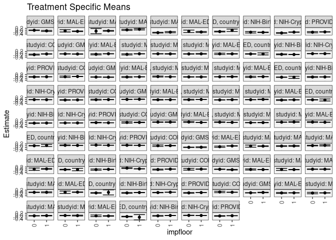

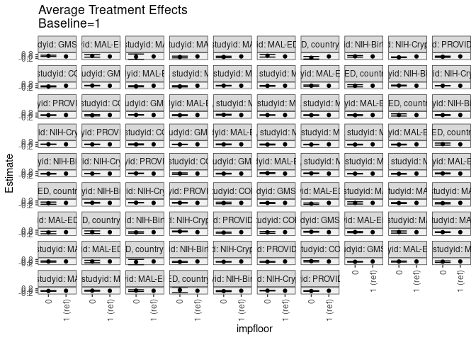

[figure not shown]

## Results Table

### Parameter: TSM

| agecat | studyid | country | intervention_level | baseline_level | estimate | ci_lower | ci_upper |
| --- | --- | --- | --- | --- | --- | --- | --- |
| 0-3 months | GMS-Nepal | NEPAL | 1 | NA | -0.0729085 | -0.1309567 | -0.0148603 |
| 0-3 months | GMS-Nepal | NEPAL | 0 | NA | -0.0113594 | -0.0439957 | 0.0212769 |
| 0-3 months | MAL-ED | BANGLADESH | 1 | NA | -0.1216269 | -0.1566598 | -0.0865940 |
| 0-3 months | MAL-ED | BANGLADESH | 0 | NA | -0.0710204 | -0.1920335 | 0.0499928 |
| 0-3 months | MAL-ED | INDIA | 1 | NA | -0.0666661 | -0.1127251 | -0.0206072 |
| 0-3 months | MAL-ED | INDIA | 0 | NA | -0.1029883 | -0.3844260 | 0.1784495 |
| 0-3 months | MAL-ED | NEPAL | 1 | NA | 0.0921189 | 0.0229420 | 0.1612957 |
| 0-3 months | MAL-ED | NEPAL | 0 | NA | 0.0347835 | -0.0242017 | 0.0937687 |
| 0-3 months | MAL-ED | PERU | 1 | NA | -0.2121764 | -0.2740329 | -0.1503198 |
| 0-3 months | MAL-ED | PERU | 0 | NA | -0.2655193 | -0.3042053 | -0.2268332 |
| 0-3 months | MAL-ED | SOUTH AFRICA | 1 | NA | -0.1956833 | -0.2501579 | -0.1412087 |
| 0-3 months | MAL-ED | SOUTH AFRICA | 0 | NA | -0.1224793 | -0.2510671 | 0.0061085 |
| 0-3 months | MAL-ED | TANZANIA, UNITED REPUBLIC OF | 1 | NA | -0.0127987 | -0.1397021 | 0.1141046 |
| 0-3 months | MAL-ED | TANZANIA, UNITED REPUBLIC OF | 0 | NA | -0.1480235 | -0.1888852 | -0.1071619 |
| 0-3 months | NIH-Birth | BANGLADESH | 1 | NA | -0.2333312 | -0.2617732 | -0.2048892 |
| 0-3 months | NIH-Birth | BANGLADESH | 0 | NA | -0.2225770 | -0.2996409 | -0.1455131 |
| 0-3 months | NIH-Crypto | BANGLADESH | 1 | NA | -0.2099055 | -0.2306501 | -0.1891609 |
| 0-3 months | NIH-Crypto | BANGLADESH | 0 | NA | -0.2983946 | -0.3270580 | -0.2697313 |
| 0-3 months | PROVIDE | BANGLADESH | 1 | NA | -0.1852206 | -0.2033338 | -0.1671074 |
| 0-3 months | PROVIDE | BANGLADESH | 0 | NA | -0.2186381 | -0.2792852 | -0.1579909 |
| 3-6 months | CONTENT | PERU | 1 | NA | 0.0178061 | -0.0055181 | 0.0411304 |
| 3-6 months | CONTENT | PERU | 0 | NA | 0.0113360 | -0.0640355 | 0.0867074 |
| 3-6 months | GMS-Nepal | NEPAL | 1 | NA | -0.1563130 | -0.2045052 | -0.1081208 |
| 3-6 months | GMS-Nepal | NEPAL | 0 | NA | -0.1624181 | -0.1859156 | -0.1389206 |
| 3-6 months | MAL-ED | BANGLADESH | 1 | NA | -0.0163428 | -0.0410660 | 0.0083804 |
| 3-6 months | MAL-ED | BANGLADESH | 0 | NA | -0.0992032 | -0.1659812 | -0.0324252 |
| 3-6 months | MAL-ED | INDIA | 1 | NA | -0.0358644 | -0.0664227 | -0.0053061 |
| 3-6 months | MAL-ED | INDIA | 0 | NA | -0.0385601 | -0.1510093 | 0.0738892 |
| 3-6 months | MAL-ED | NEPAL | 1 | NA | -0.0154076 | -0.0569859 | 0.0261708 |
| 3-6 months | MAL-ED | NEPAL | 0 | NA | -0.0291145 | -0.0650593 | 0.0068302 |

[output cut: 144 more lines]

### Parameter: E(Y)

| agecat | studyid | country | intervention_level | baseline_level | estimate | ci_lower | ci_upper |
| --- | --- | --- | --- | --- | --- | --- | --- |
| 0-3 months | GMS-Nepal | NEPAL | NA | NA | -0.0224939 | -0.0513092 | 0.0063213 |
| 0-3 months | MAL-ED | BANGLADESH | NA | NA | -0.1175527 | -0.1512522 | -0.0838531 |
| 0-3 months | MAL-ED | INDIA | NA | NA | -0.0689235 | -0.1155446 | -0.0223023 |
| 0-3 months | MAL-ED | NEPAL | NA | NA | 0.0580999 | 0.0129700 | 0.1032298 |
| 0-3 months | MAL-ED | PERU | NA | NA | -0.2543887 | -0.2877193 | -0.2210580 |
| 0-3 months | MAL-ED | SOUTH AFRICA | NA | NA | -0.1882890 | -0.2390479 | -0.1375301 |
| 0-3 months | MAL-ED | TANZANIA, UNITED REPUBLIC OF | NA | NA | -0.1419596 | -0.1815730 | -0.1023462 |
| 0-3 months | NIH-Birth | BANGLADESH | NA | NA | -0.2321299 | -0.2588226 | -0.2054373 |
| 0-3 months | NIH-Crypto | BANGLADESH | NA | NA | -0.2312607 | -0.2486732 | -0.2138483 |
| 0-3 months | PROVIDE | BANGLADESH | NA | NA | -0.1880402 | -0.2054115 | -0.1706689 |
| 3-6 months | CONTENT | PERU | NA | NA | 0.0173829 | -0.0049673 | 0.0397330 |
| 3-6 months | GMS-Nepal | NEPAL | NA | NA | -0.1612796 | -0.1824038 | -0.1401554 |
| 3-6 months | MAL-ED | BANGLADESH | NA | NA | -0.0224408 | -0.0460321 | 0.0011506 |
| 3-6 months | MAL-ED | INDIA | NA | NA | -0.0360402 | -0.0655320 | -0.0065484 |
| 3-6 months | MAL-ED | NEPAL | NA | NA | -0.0230158 | -0.0502389 | 0.0042072 |
| 3-6 months | MAL-ED | PERU | NA | NA | 0.0257461 | -0.0055184 | 0.0570106 |
| 3-6 months | MAL-ED | SOUTH AFRICA | NA | NA | -0.0016619 | -0.0396107 | 0.0362870 |
| 3-6 months | MAL-ED | TANZANIA, UNITED REPUBLIC OF | NA | NA | -0.0691618 | -0.1015337 | -0.0367899 |
| 3-6 months | NIH-Birth | BANGLADESH | NA | NA | -0.0502117 | -0.0723801 | -0.0280432 |
| 3-6 months | NIH-Crypto | BANGLADESH | NA | NA | 0.0267740 | 0.0099602 | 0.0435879 |
| 3-6 months | PROVIDE | BANGLADESH | NA | NA | -0.0269625 | -0.0428628 | -0.0110622 |
| 6-9 months | CONTENT | PERU | NA | NA | -0.0236130 | -0.0439514 | -0.0032747 |
| 6-9 months | GMS-Nepal | NEPAL | NA | NA | -0.0468499 | -0.0677826 | -0.0259172 |
| 6-9 months | MAL-ED | BANGLADESH | NA | NA | -0.0700232 | -0.0872813 | -0.0527650 |
| 6-9 months | MAL-ED | INDIA | NA | NA | -0.0703356 | -0.0932354 | -0.0474358 |
| 6-9 months | MAL-ED | NEPAL | NA | NA | -0.0326076 | -0.0521325 | -0.0130827 |
| 6-9 months | MAL-ED | PERU | NA | NA | -0.0335784 | -0.0576919 | -0.0094649 |
| 6-9 months | MAL-ED | SOUTH AFRICA | NA | NA | -0.0177828 | -0.0459046 | 0.0103391 |
| 6-9 months | MAL-ED | TANZANIA, UNITED REPUBLIC OF | NA | NA | -0.0920985 | -0.1257957 | -0.0584013 |
| 6-9 months | NIH-Birth | BANGLADESH | NA | NA | -0.0592348 | -0.0771184 | -0.0413511 |

[output cut: 57 more lines]

### Parameter: ATE

| agecat | studyid | country | intervention_level | baseline_level | estimate | ci_lower | ci_upper |
| --- | --- | --- | --- | --- | --- | --- | --- |
| 0-3 months | GMS-Nepal | NEPAL | 1 | 1 | 0.0000000 | 0.0000000 | 0.0000000 |
| 0-3 months | GMS-Nepal | NEPAL | 0 | 1 | 0.0615491 | -0.0050446 | 0.1281428 |
| 0-3 months | MAL-ED | BANGLADESH | 1 | 1 | 0.0000000 | 0.0000000 | 0.0000000 |
| 0-3 months | MAL-ED | BANGLADESH | 0 | 1 | 0.0506065 | -0.0753756 | 0.1765887 |
| 0-3 months | MAL-ED | INDIA | 1 | 1 | 0.0000000 | 0.0000000 | 0.0000000 |
| 0-3 months | MAL-ED | INDIA | 0 | 1 | -0.0363221 | -0.3215038 | 0.2488596 |
| 0-3 months | MAL-ED | NEPAL | 1 | 1 | 0.0000000 | 0.0000000 | 0.0000000 |
| 0-3 months | MAL-ED | NEPAL | 0 | 1 | -0.0573354 | -0.1482457 | 0.0335750 |
| 0-3 months | MAL-ED | PERU | 1 | 1 | 0.0000000 | 0.0000000 | 0.0000000 |
| 0-3 months | MAL-ED | PERU | 0 | 1 | -0.0533429 | -0.1263007 | 0.0196149 |
| 0-3 months | MAL-ED | SOUTH AFRICA | 1 | 1 | 0.0000000 | 0.0000000 | 0.0000000 |
| 0-3 months | MAL-ED | SOUTH AFRICA | 0 | 1 | 0.0732040 | -0.0664467 | 0.2128547 |
| 0-3 months | MAL-ED | TANZANIA, UNITED REPUBLIC OF | 1 | 1 | 0.0000000 | 0.0000000 | 0.0000000 |
| 0-3 months | MAL-ED | TANZANIA, UNITED REPUBLIC OF | 0 | 1 | -0.1352248 | -0.2685445 | -0.0019051 |
| 0-3 months | NIH-Birth | BANGLADESH | 1 | 1 | 0.0000000 | 0.0000000 | 0.0000000 |
| 0-3 months | NIH-Birth | BANGLADESH | 0 | 1 | 0.0107542 | -0.0713907 | 0.0928991 |
| 0-3 months | NIH-Crypto | BANGLADESH | 1 | 1 | 0.0000000 | 0.0000000 | 0.0000000 |
| 0-3 months | NIH-Crypto | BANGLADESH | 0 | 1 | -0.0884891 | -0.1238717 | -0.0531065 |
| 0-3 months | PROVIDE | BANGLADESH | 1 | 1 | 0.0000000 | 0.0000000 | 0.0000000 |
| 0-3 months | PROVIDE | BANGLADESH | 0 | 1 | -0.0334175 | -0.0967117 | 0.0298768 |
| 3-6 months | CONTENT | PERU | 1 | 1 | 0.0000000 | 0.0000000 | 0.0000000 |
| 3-6 months | CONTENT | PERU | 0 | 1 | -0.0064702 | -0.0853680 | 0.0724277 |
| 3-6 months | GMS-Nepal | NEPAL | 1 | 1 | 0.0000000 | 0.0000000 | 0.0000000 |
| 3-6 months | GMS-Nepal | NEPAL | 0 | 1 | -0.0061050 | -0.0597205 | 0.0475104 |
| 3-6 months | MAL-ED | BANGLADESH | 1 | 1 | 0.0000000 | 0.0000000 | 0.0000000 |
| 3-6 months | MAL-ED | BANGLADESH | 0 | 1 | -0.0828604 | -0.1540681 | -0.0116527 |
| 3-6 months | MAL-ED | INDIA | 1 | 1 | 0.0000000 | 0.0000000 | 0.0000000 |
| 3-6 months | MAL-ED | INDIA | 0 | 1 | -0.0026957 | -0.1192231 | 0.1138317 |
| 3-6 months | MAL-ED | NEPAL | 1 | 1 | 0.0000000 | 0.0000000 | 0.0000000 |
| 3-6 months | MAL-ED | NEPAL | 0 | 1 | -0.0137070 | -0.0686686 | 0.0412546 |

[output cut: 144 more lines]

### Parameter: PAR

| agecat | studyid | country | intervention_level | baseline_level | estimate | ci_lower | ci_upper |
| --- | --- | --- | --- | --- | --- | --- | --- |
| 0-3 months | GMS-Nepal | NEPAL | 1 | NA | 0.0504146 | -0.0041818 | 0.1050109 |
| 0-3 months | MAL-ED | BANGLADESH | 1 | NA | 0.0040743 | -0.0062200 | 0.0143685 |
| 0-3 months | MAL-ED | INDIA | 1 | NA | -0.0022573 | -0.0200277 | 0.0155131 |
| 0-3 months | MAL-ED | NEPAL | 1 | NA | -0.0340190 | -0.0881484 | 0.0201104 |
| 0-3 months | MAL-ED | PERU | 1 | NA | -0.0422123 | -0.1000084 | 0.0155838 |
| 0-3 months | MAL-ED | SOUTH AFRICA | 1 | NA | 0.0073943 | -0.0070442 | 0.0218329 |
| 0-3 months | MAL-ED | TANZANIA, UNITED REPUBLIC OF | 1 | NA | -0.1291609 | -0.2565553 | -0.0017665 |
| 0-3 months | NIH-Birth | BANGLADESH | 1 | NA | 0.0012013 | -0.0079788 | 0.0103813 |
| 0-3 months | NIH-Crypto | BANGLADESH | 1 | NA | -0.0213552 | -0.0303309 | -0.0123796 |
| 0-3 months | PROVIDE | BANGLADESH | 1 | NA | -0.0028196 | -0.0082084 | 0.0025692 |
| 3-6 months | CONTENT | PERU | 1 | NA | -0.0004233 | -0.0055893 | 0.0047427 |
| 3-6 months | GMS-Nepal | NEPAL | 1 | NA | -0.0049665 | -0.0485841 | 0.0386511 |
| 3-6 months | MAL-ED | BANGLADESH | 1 | NA | -0.0060979 | -0.0120376 | -0.0001583 |
| 3-6 months | MAL-ED | INDIA | 1 | NA | -0.0001758 | -0.0077759 | 0.0074243 |
| 3-6 months | MAL-ED | NEPAL | 1 | NA | -0.0076083 | -0.0381285 | 0.0229120 |
| 3-6 months | MAL-ED | PERU | 1 | NA | -0.0194891 | -0.0759856 | 0.0370073 |
| 3-6 months | MAL-ED | SOUTH AFRICA | 1 | NA | -0.0025768 | -0.0126983 | 0.0075448 |
| 3-6 months | MAL-ED | TANZANIA, UNITED REPUBLIC OF | 1 | NA | -0.0005215 | -0.1287016 | 0.1276586 |
| 3-6 months | NIH-Birth | BANGLADESH | 1 | NA | -0.0029643 | -0.0109999 | 0.0050713 |
| 3-6 months | NIH-Crypto | BANGLADESH | 1 | NA | 0.0186132 | 0.0077313 | 0.0294950 |
| 3-6 months | PROVIDE | BANGLADESH | 1 | NA | -0.0034624 | -0.0077873 | 0.0008624 |
| 6-9 months | CONTENT | PERU | 1 | NA | -0.0010661 | -0.0073324 | 0.0052002 |
| 6-9 months | GMS-Nepal | NEPAL | 1 | NA | 0.0349677 | -0.0017294 | 0.0716649 |
| 6-9 months | MAL-ED | BANGLADESH | 1 | NA | 0.0007765 | -0.0039546 | 0.0055075 |
| 6-9 months | MAL-ED | INDIA | 1 | NA | 0.0009687 | -0.0063262 | 0.0082637 |
| 6-9 months | MAL-ED | NEPAL | 1 | NA | 0.0005389 | -0.0208701 | 0.0219480 |
| 6-9 months | MAL-ED | PERU | 1 | NA | -0.0032985 | -0.0486906 | 0.0420937 |
| 6-9 months | MAL-ED | SOUTH AFRICA | 1 | NA | -0.0006419 | -0.0106747 | 0.0093909 |
| 6-9 months | MAL-ED | TANZANIA, UNITED REPUBLIC OF | 1 | NA | -0.0538946 | -0.3150083 | 0.2072190 |
| 6-9 months | NIH-Birth | BANGLADESH | 1 | NA | -0.0041038 | -0.0095212 | 0.0013136 |

[output cut: 57 more lines]